# DelayCueAdapt20160426

Upon a visit a delay timer of 1.5s starts then a light cue appears for 1.5s within the time of the light cue it is possible to open the door with a nosepoke, otherwise it counts as a time error.

This R markdown requires ggplot2 package and will install it if it doesn't exist.

It read the “animals.txt”, “visits.txt” and “nosepokes.txt” files, removes all non-first nosepokes

and assigns animal name for each event as a factor(visit and nosepoke).

This is the visit count with the appropriate plot

```
##
## Animal 13  Animal 2  Animal 4  Animal 5  Animal 6  Animal 9
##       718       510       427       658       747       684
```

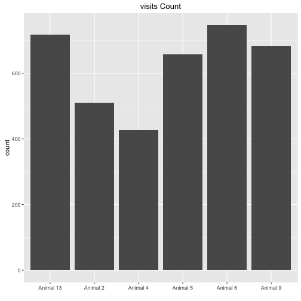

Visits over time for each animal

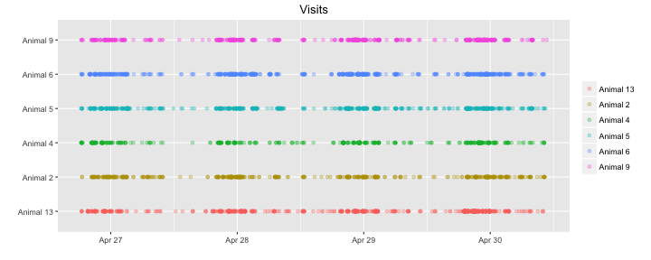

Visit count across absoulute time

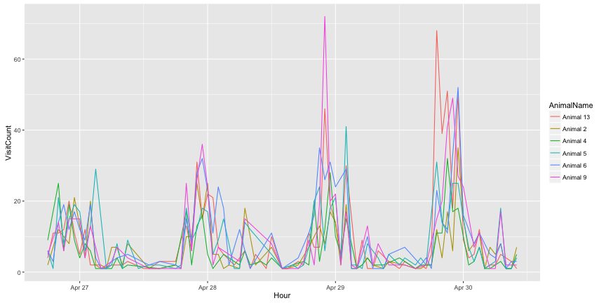

This is the hour with the maximun number of visits

```
## [1] "2016-04-29 23:00:00 IDT"
```

This is the nosepokes count with the appropriate plot

```
##
## Animal 13  Animal 2  Animal 4  Animal 5  Animal 6  Animal 9
##       642       412       322       513       630       501
```

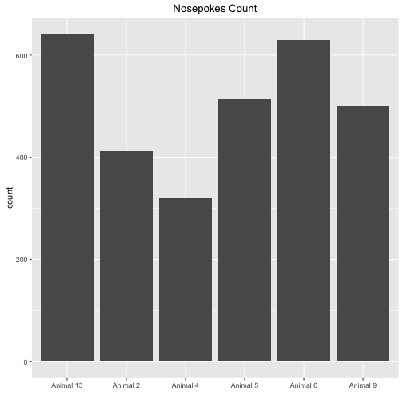

Nosepokes over time for each animal

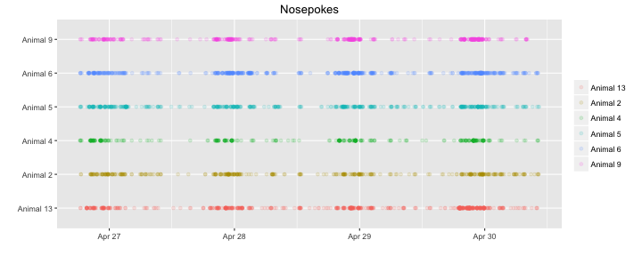

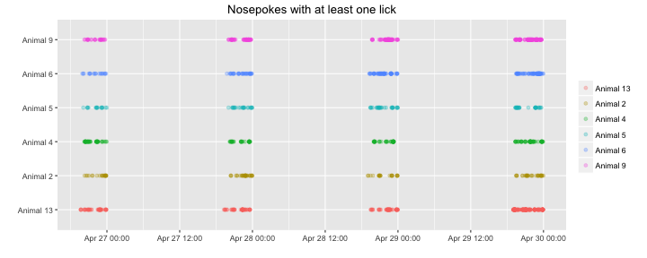

This is a plot showing the amount of nosepokes in the time window per day per animal

[output not shown]

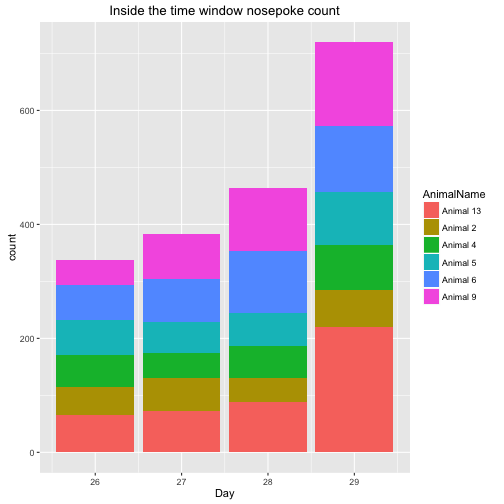

This is a plot showing the fraction of errors per time window per module, the number of the module corresponds the anticipation time in seconds.

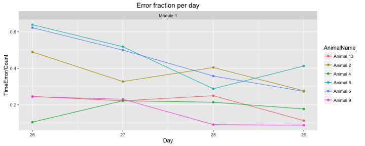

```
##    AnimalName Day ModuleName Count TimeError
## 1   Animal 13  26   Module 1    65        16
## 2    Animal 9  26   Module 1    45        11
## 3    Animal 5  26   Module 1    61        39
## 4    Animal 6  26   Module 1    61        38
## 5    Animal 4  26   Module 1    57         6
## 6    Animal 2  26   Module 1    49        24
## 7   Animal 13  27   Module 1    72        16
## 8    Animal 9  27   Module 1    78        18
## 9    Animal 5  27   Module 1    54        28
## 10   Animal 6  27   Module 1    76        38
## 11   Animal 4  27   Module 1    45        10
## 12   Animal 2  27   Module 1    58        19
## 13  Animal 13  28   Module 1    88        22
## 14   Animal 9  28   Module 1   109        10
## 15   Animal 5  28   Module 1    59        17
## 16   Animal 6  28   Module 1   109        39
## 17   Animal 4  28   Module 1    56        12
## 18   Animal 2  28   Module 1    42        17
## 19  Animal 13  29   Module 1   220        25
## 20   Animal 9  29   Module 1   147        13
## 21   Animal 5  29   Module 1    92        38
## 22   Animal 6  29   Module 1   117        32
## 23   Animal 4  29   Module 1    79        14
## 24   Animal 2  29   Module 1    65        18
```

This is an histogram showing the reaction times(values under zero are nosepokes before the light cue) by Day by anticipation time, the salmon colored line is the overall median reaction time:

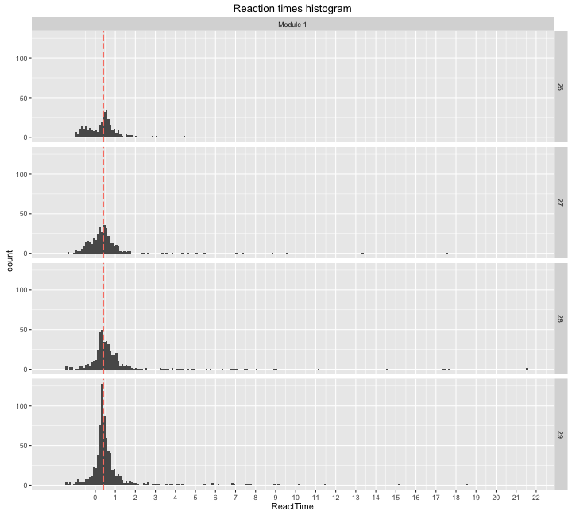

```
## [1] "The median reaction time in seconds:0.420000076293945"
```

This is an histogram showing the reaction times(values under zero are nosepokes before the light cue) by animal by day, the salmon colored line is the overall median reaction time:

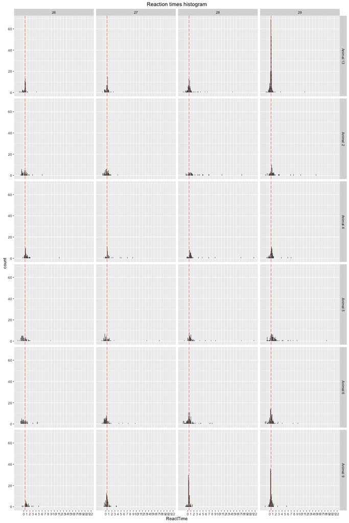

##Conclusion  
The mice finally associate the light cue with the possibility to open then door.